# Generating ready-to-analyze datasets with GRD

This vignette illustrate some of its use.

## Simplest specification

The simplest use relies on the default value:

```r
dta <- GRD()
head(dta)
```

```
##   id         DV
## 1  1  2.0040741
## 2  2  0.2759187
## 3  3  1.8719461
## 4  4 -0.8682997
## 5  5 -0.8987161
## 6  6 -0.6247305
```

By default, one hundred scores are generated from a normal distribution with mean 0 and standard deviation of 1. In other words, it generate 100 z scores. The dependent variable, the last column in the dataframe that will be generated is called by default `DV`. The first column is an “id” column containing a number identifying each *simulated* participant. To change the dependent variable’s name, use

```r
dta <- GRD( RenameDV = "score" )
```

### Data from a design with between-subject factors and within-subject factors.

To add various groups to the dataset, use the argument `BSFactors`, as in

```r
dta <- GRD( BSFactors = 'Group(3)')
```

There will be 100 random z scores in each of three groups, for a total of 300 data. The group number will be given in an additional column, here called `Group`. A factorial design can be generated with more than one factors, such as

```r
dta <- GRD( BSFactors = c('Surgery(2)', 'Therapy(3)') )
```

which will results in 2 $\times$ 3, that is, 6 different groups, crossing all the levels of Surgery (1 and 2) and all the levels of Therapy (1, 2 and 3). The levels can receive names rather than number, as in

```r
dta <- GRD(
    BSFactors = c('Surgery(yes, no)', 'Therapy(CBT,Control,Exercise)')
)
unique(dta$Surgery)
```

```
## [1] "yes" "no"
```

```r
unique(dta$Therapy)
```

```
## [1] "CBT"      "Control"  "Exercise"
```

Finally, within-subject factors can also be given, as in

```r
dta <- GRD(
    BSFactors = c('Surgery(yes,no)', 'Therapy(CBT, Control,Exercise)'),
    WSFactors = 'Contrast(C1,C2,C3)',
)
```

For within-subject designs, the repeated measures will appear in distinct columns (here “DV.C1,” “DV.C2,” and “DV.C3” ). This format is called **wide** format, meaning that the repeated measures are all on the same line for a given *simulated* participant.

## Deciding the sample sizes

The default is to generate 100 participants in each between-subject groups. This default can be changed with `SubjectsPerGroup`. The most straigthforward specification is, e.g., `SubjectsPerGroup = 25` for 25 participants in each groups. Unequal group sizes can be specified with:

```r
dta <- GRD(
    BSFactors = "Therapy(3)",
    SubjectsPerGroup = c(2, 5, 1)
)
dta
```

```
##   id Therapy          DV
## 1  1       1 -1.68129263
## 2  2       1 -0.07926723
## 3  3       2  0.29432574
## 4  4       2  0.45926089
## 5  5       2  1.45403516
## 6  6       2  1.05701939
## 7  7       2  2.36381252
## 8  8       3  0.44643127
```

## Choosing the population distribution

To sample random data, it is necessary to specify a theoretical population distribution. The default is to use a normal distribution (the famous “bell-shaped” curve). That population has a grand mean (`GM`, $\mu$) given by the element `mean` and standard deviation ($\sigma$) given by the element `stddev`. These can be redefined using the argument `Population` with a list of the relevant elements. In the following example, IQ are being simulated with :

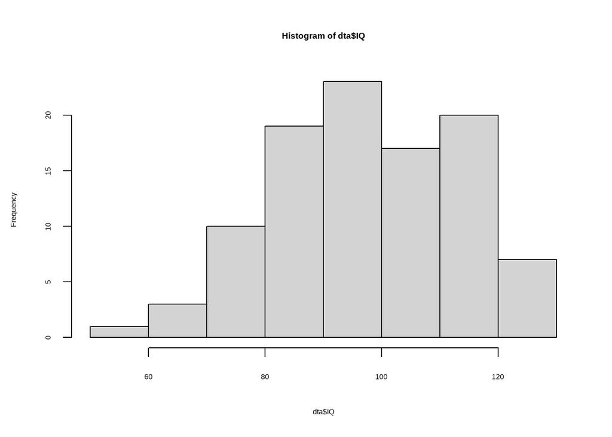

```r
dta <- GRD(
    RenameDV = "IQ",
    Population=list(mean=100,stddev=15)
)
hist(dta$IQ)
```

(increase the number of participants using `SubjectsPerGroup` to say 10,000, and the bell-shape curve will be evident!).

Internally, the above call to `GRD()` will use `rnorm` to generate the scores, passing along for the mean parameter the grand mean (internally called `GM`) and for the standard deviation parameter the provided standard deviation (internally called `STDDEV`). This can be explicitly stated using the element `scores` as in:

```r
dta <- GRD(
    BSFactors = "Group(2)",
    Population = list(
        mean   = 100,         # this set GM to 100
        stddev = 15,        # this set STDDEV to 15
        scores = "rnorm(1, mean = GM, sd = STDDEV )"
    )
)
```

Using `scores`, it is possible to alter the parameters, for example, have a mean proportional to the group number, or the standard deviation proportional to the group number, as in:

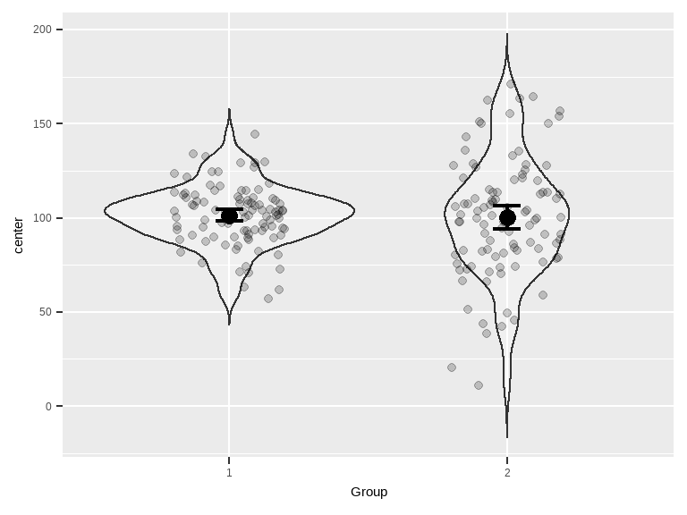

```r
dta <- GRD(
    BSFactors = "Group(2)",
    Population = list(
        mean   = 100,       # this set GM to 100
        stddev = 15,        # this set STDDEV to 15
        scores = "rnorm(1, mean = GM, sd = Group * STDDEV )"
    )
)
superbPlot(dta,
    BSFactors = "Group",
    variables = "DV",
    plotStyle = "pointjitterviolin" )
```

Any valid R instruction could be placed in the `scores` arguments, such as `scores = "rnorm(1, mean = GM, sd = ifelse(Group==1,10,50) )"` to select the standard deviation according to `Group` or `scores = "1"` to generate constants. Other theoretical distributions can also be chosen, as in:

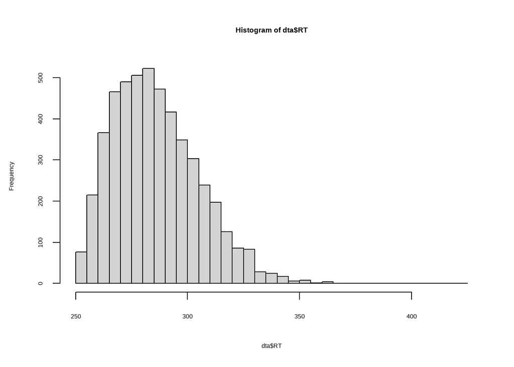

```r
dta <- GRD(SubjectsPerGroup = 5000,
    RenameDV = "RT",
    Population=list(
        scores = "rweibull(1, shape=2, scale=40)+250"
    )
)
hist(dta$RT,breaks=seq(250,425,by=5))
```

## Getting effects on one or some of the factors

It is possible to generate non-null effects on the factors using the argument `Effects`. Effects can be `slope(x)` (an increase of x points for each level of the factor), `extent(x)` (a total increase of `x` over all the levels), `custom(x, y, etc)` for an effect of `x` point for the first level of the factor, `y` point for the second, etc.

Here is a slope effect:

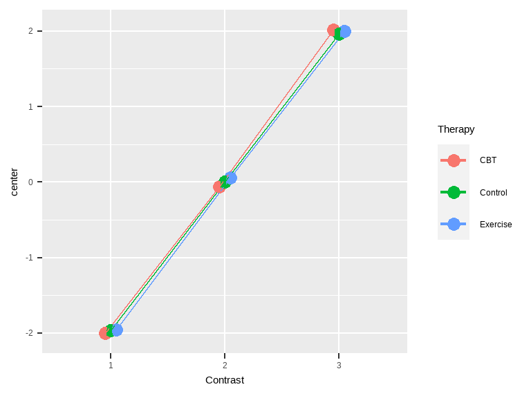

```r
dta <- GRD(
    BSFactors = 'Therapy(CBT, Control, Exercise)',
    WSFactors = 'Contrast(3)',
    SubjectsPerGroup = 1000,
    Effects = list('Contrast' = slope(2))
)
superbPlot(dta,
    BSFactors = "Therapy", WSFactors = "Contrast(3)",
    variables = c("DV.1","DV.2","DV.3"),
    plotStyle = "line" )
```

Effects can also be any R code manipulating the factors, using `Rexpression`. One example:

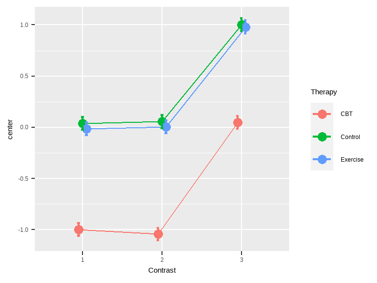

```r
dta <- GRD(
    BSFactors = 'Therapy(CBT,Control,Exercise)',
    WSFactors = 'Contrast(3) ',
    SubjectsPerGroup = 1000,
    Effects = list(
        "code1"=Rexpression("if (Therapy =='CBT'){-1} else {0}"),
        "code2"=Rexpression("if (Contrast ==3) {+1} else {0}")
    )
)
superbPlot(dta,
    BSFactors = "Therapy", WSFactors = "Contrast(3)",
    variables = c("DV.1","DV.2","DV.3"),
    plotStyle = "line" )
```

Repeated measures can also be generated from a multivariate normal distribution with a correlation `rho`, with, e.g.,

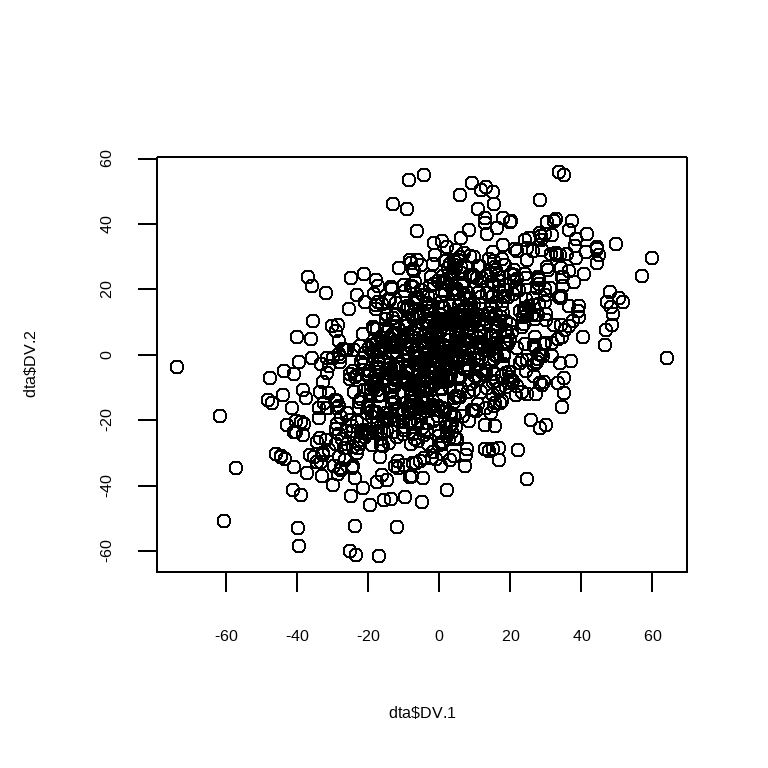

```r
dta <- GRD(
    WSFactors = 'Difficulty(1, 2)',
    SubjectsPerGroup = 1000,
    Population=list(mean = 0,stddev = 20, rho = 0.5)
)
plot(dta$DV.1, dta$DV.2)
```

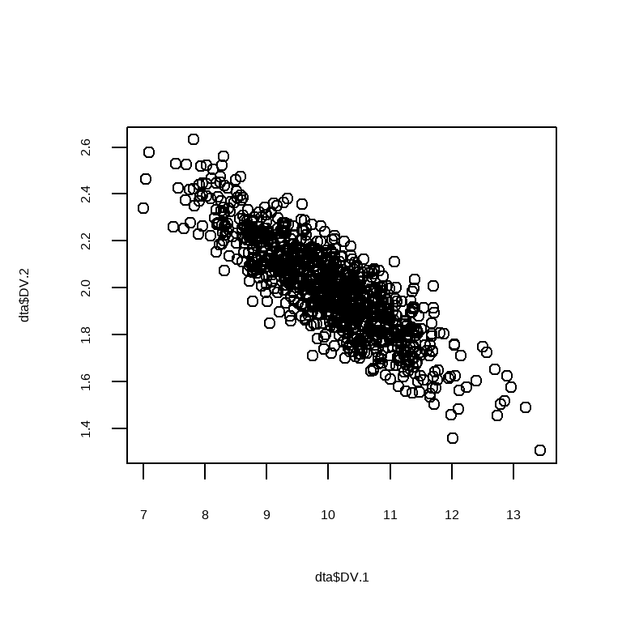

```r
dta <- GRD(
    WSFactors = 'Difficulty(1, 2)',
    SubjectsPerGroup = 1000,
    Population=list(mean = c(10,2),stddev= c(1,0.2),rho =-0.85)
)
plot(dta$DV.1, dta$DV.2)
```

## Contaminate your samples!

Contaminants can be inserted in the simulated data using `Contaminant`. This argument works exactly like `Population` except for the additional option `proportion` which indicates the proportion of contaminants in the samples:

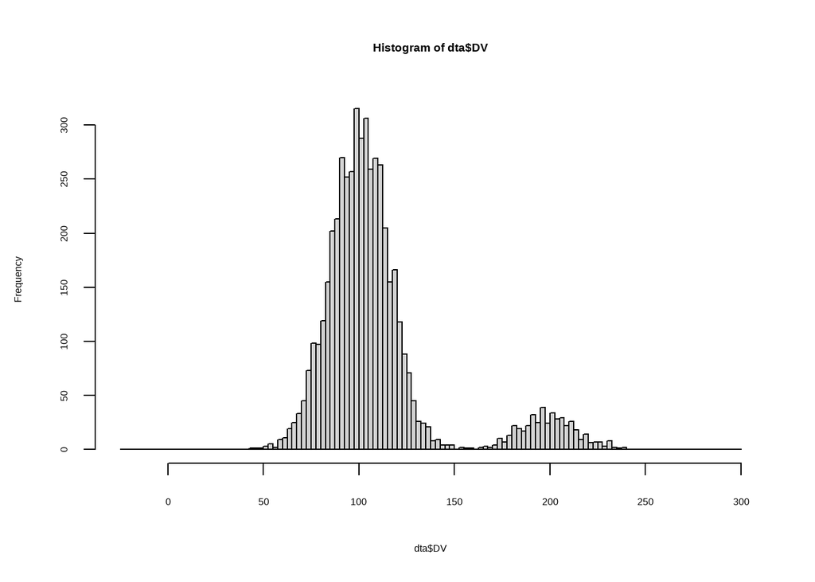

```r
dta <- GRD(SubjectsPerGroup = 5000,
    Population= list( mean=100, stddev = 15 ),
    Contaminant=list( mean=200, stddev = 15, proportion = 0.10 )
)
hist(dta$DV,breaks=seq(-25,300,by=2.5))
```

Contaminants can be normally distributed (as above) or come from any theoretical distribution which can be simulated in R:

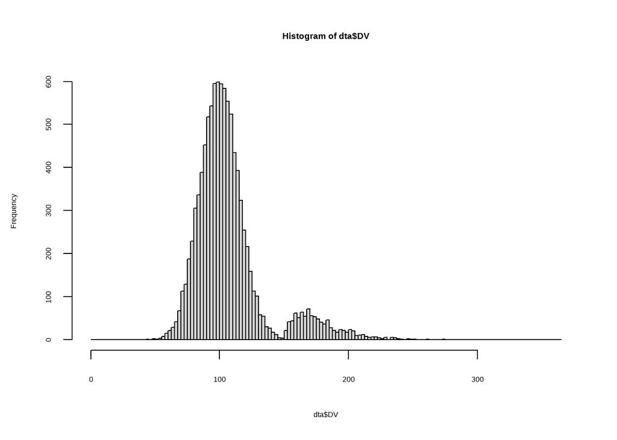

```r
dta <- GRD(SubjectsPerGroup = 10000,
    Population=list( mean=100, stddev = 15 ),
    Contaminant=list( proportion = 0.10,
        scores="rweibull(1,shape=1.5, scale=30)+1.5*GM")
)
hist(dta$DV,breaks=seq(0,365,by=2.5))
```

Finally, contaminants can be used to add missing data (missing completely at random) with:

```r
dta <- GRD( BSFactors="grp(2)",
    WSFactors = "Moment (2)",
    SubjectsPerGroup = 1000,
    Effects = list("grp" = slope(100) ),
    Population=list(mean=0,stddev=20,rho= -0.85),
    Contaminant=list(scores = "NA", proportion=0.2)
)
```

## In summary

`GRD()` is a convenient function to generate about any sorts of data sets with any form of effects. The data can simulate any factorial designs involving between-subject designs, repeated-measure designs, and multivariate data.

One use if of course in the classroom: students can test their skill by generating random data sets and run statistical procedures. To illustrate type-I errors, it become then easy to generate data with no effect whatsoever and ask the students who obtain a rejection decision to raise their hand.

# References

Calderini, M., & Harding, B. (2019). GRD for R: An intuitive tool for generating random data in R. *The Quantitative Methods for Psychology*, *15*(1), 1–11. https://doi.org/10.20982/tqmp.15.1.p001

Cousineau, D. (2020). In-class activity comparing standard errors as a function of sample size with SPSS. *The Quantitative Methods for Psychology*, *16*(2), v4–v7. https://doi.org/10.20982/tqmp.16.2.v009

Harding, B., & Cousineau, D. (2014). GRD: An SPSS extension command for generating random data. *The Quantitative Methods for Psychology*, *10*(2), 80–94. https://doi.org/10.20982/tqmp.10.2.p080

Harding, B., & Cousineau, D. (2015). An extended SPSS extension command for generating random data. *The Quantitative Methods for Psychology*, *11*(3), 127–138. https://doi.org/10.20982/tqmp.11.3.p127